# Homework 2: Supervised Learning Models

## Part 1: Regression on California Test Scores

```python
#load initial libraries
import pandas as pd
import numpy as np
from sklearn.model_selection import train_test_split
from sklearn.linear_model import LinearRegression
import seaborn as sns
```

```python
#load California Test Scores
url = 'https://vincentarelbundock.github.io/Rdatasets/csv/Ecdat/Caschool.csv'
df = pd.read_csv(url)
```

```python
#explore info
df.info()
```

```
<class 'pandas.core.frame.DataFrame'>
RangeIndex: 420 entries, 0 to 419
Data columns (total 18 columns):
Unnamed: 0    420 non-null int64
distcod       420 non-null int64
county        420 non-null object
district      420 non-null object
grspan        420 non-null object
enrltot       420 non-null int64
teachers      420 non-null float64
calwpct       420 non-null float64
mealpct       420 non-null float64
computer      420 non-null int64
testscr       420 non-null float64
compstu       420 non-null float64
expnstu       420 non-null float64
str           420 non-null float64
avginc        420 non-null float64
elpct         420 non-null float64
readscr       420 non-null float64
mathscr       420 non-null float64
dtypes: float64(11), int64(4), object(3)
memory usage: 59.1+ KB
```

### 1.1 Visualize the univariate distribution of the target feature and each of the three continuous explanatory variables that you think are likely to have a relationship with the target feature.

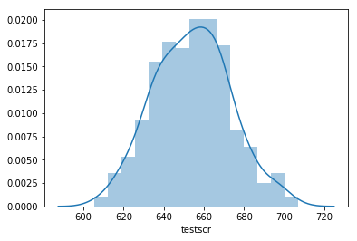

```python
#univariate plot of target data, test score
sns.distplot(df.testscr)
```

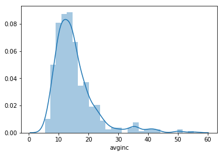

```python
#univariate plot of average income of the district
sns.distplot(df.avginc)
```

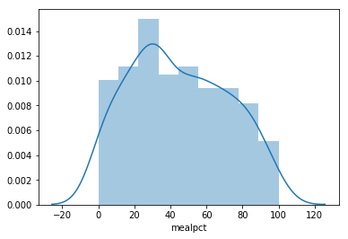

```python
#univariate plot of free and reduced lunch percentage
sns.distplot(df.mealpct)
```

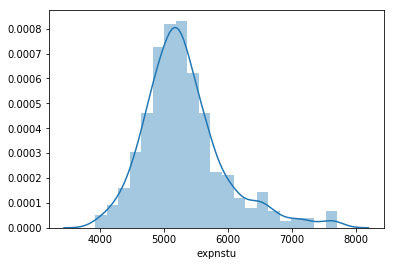

```python
#univariate plot of expenditure per student
sns.distplot(df.expnstu)
```

### 1.2 Visualize the dependency of the target on each feature from 1.1.

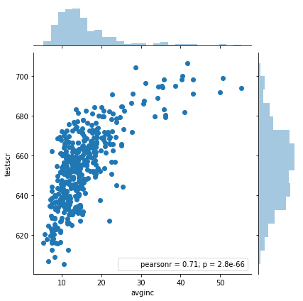

```python
#correlation plot between target and average income of district.
#There is a positive correlation between income and test score
sns.jointplot('avginc', 'testscr', data = df, kind='scatter')
```

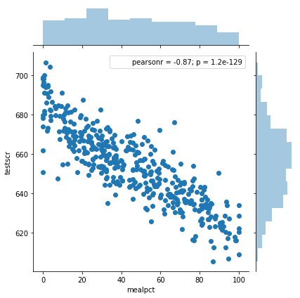

```python
#correlation plot between target and % free and reduced lunch
#There is a strong negative correlation between percentage free and reduced lunch and test score
sns.jointplot('mealpct', 'testscr', data = df, kind='scatter')
```

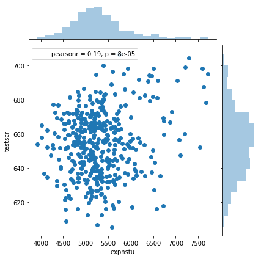

```python
#correlation plot between target and expenditure per student
#there is a weak correlation between expenditure per student and test score.
sns.jointplot('expnstu', 'testscr', data = df, kind='scatter')
```

### 1.3 Split data in training and test set. Build models that evaluate the relationship between all available X variables in the California test dataset and the target variable. Evaluate KNN for regression, Linear Regression (OLS), Ridge, and Lasso using cross-validation with the default parameters. Does scaling the data with the StandardScaler help?

```python
#remove readscr and mathscr bc they formed target, also remove non-numeric data
df = df.drop(['Unnamed: 0','readscr', 'mathscr','distcod','county','district','grspan'], axis=1)

#set X and Y
X = df.loc[:, df.columns != 'testscr']
y = df['testscr']
```

```python
#split data to train test
X_train, X_test, y_train, y_test = train_test_split(X, y, random_state=42)
#create linear regression model
lr = LinearRegression().fit(X_train, y_train)
```

```python
#print coefficents and intercept
print("lr.coef_: {}".format(lr.coef_))
print("lr.intercept_: {}".format(lr.intercept_))
```

```
lr.coef_: [ 2.37299343e-04 -9.68465212e-03 -1.05122232e-01 -3.63632211e-01
  2.23981150e-03 -1.50110373e+00  1.87297506e-03 -3.68530746e-01
  5.17180694e-01 -1.97462843e-01]
lr.intercept_: 664.1994881014358
```

```python
#print training and test set performance
print("Training set score: {:.2f}".format(lr.score(X_train, y_train)))
print("Test set score: {:.2f}".format(lr.score(X_test, y_test)))

#cross validation, 10 splits
from sklearn.model_selection import cross_val_score

scores = cross_val_score(lr, X_train, y_train, cv=10)
print("Cross-validation scores: {}".format(scores))
cvmean = np.mean(cross_val_score(LinearRegression(), X_train, y_train, cv=10))
print("Cross-validation mean: " + str(cvmean))
#The model is 81% accurate on both the training and test set
```

```
Training set score: 0.81
Test set score: 0.81
Cross-validation scores: [0.83584317 0.82663519 0.81727054 0.73244216 0.66777597 0.79661975
 0.81683622 0.77893159 0.75857274 0.76232761]
Cross-validation mean: 0.7793254938876505
```

#### Ridge

```python
#ridge regression, alpha set to default, 1
from sklearn.linear_model import Ridge
ridge = Ridge().fit(X_train, y_train)
print("Training set score: {:.2f}".format(ridge.score(X_train, y_train)))
print("Test set score: {:.2f}".format(ridge.score(X_test, y_test)))
 #same performance
```

```
Training set score: 0.81
Test set score: 0.81
```

```python
 # ridge with larger alpha, 10
ridge10 = Ridge(alpha=10).fit(X_train, y_train)
print("Training set score: {:.2f}".format(ridge10.score(X_train, y_train)))
print("Test set score: {:.2f}".format(ridge10.score(X_test, y_test)))
 #same performance
```

```
Training set score: 0.81
Test set score: 0.81
```

```python
#ridge with smaller alpha, .1
ridge01 = Ridge(alpha=0.1).fit(X_train, y_train)
print("Training set score: {:.2f}".format(ridge01.score(X_train, y_train)))
print("Test set score: {:.2f}".format(ridge01.score(X_test, y_test)))

 #same performance
```

```
Training set score: 0.81
Test set score: 0.81
```

#### Lasso

```python
#Lasso Regression
from sklearn.linear_model import Lasso
lasso = Lasso().fit(X_train, y_train)
print("Training set score: {:.2f}".format(lasso.score(X_train, y_train)))
print("Test set score: {:.2f}".format(lasso.score(X_test, y_test)))
print("Number of features used: {}".format(np.sum(lasso.coef_ != 0)))
print("Number of features used: {}".format(np.sum(lasso.coef_ != 0)))

print("lasso.coef_: {}".format(lasso.coef_))
#model performed slightly worse on this training set
```

```
Training set score: 0.80
Test set score: 0.81
Number of features used: 8
Number of features used: 8
lasso.coef_: [-3.49584411e-04  2.48458337e-03 -8.87553845e-02 -3.79258646e-01
  1.92100909e-03  0.00000000e+00  2.48224777e-03 -0.00000000e+00
  4.81690728e-01 -1.86583901e-01]
```

```python
# Smaller alpha for a more complex model

lasso001 = Lasso(alpha=0.01, max_iter=100000).fit(X_train, y_train)
print("Training set score: {:.2f}".format(lasso001.score(X_train, y_train)))
print("Test set score: {:.2f}".format(lasso001.score(X_test, y_test)))
print("Number of features used: {}".format(np.sum(lasso001.coef_ != 0)))
```

```
Training set score: 0.81
Test set score: 0.81
Number of features used: 9
```

```python
#even smaller alpha
lasso00001 = Lasso(alpha=0.0001, max_iter=100000).fit(X_train, y_train)
print("Training set score: {:.2f}".format(lasso00001.score(X_train, y_train)))
print("Test set score: {:.2f}".format(lasso00001.score(X_test, y_test)))
print("Number of features used: {}".format(np.sum(lasso00001.coef_ != 0)))
```

```
Training set score: 0.81
Test set score: 0.81
Number of features used: 10
```

```
Text(0,0.5,'Coefficient magnitude')
```

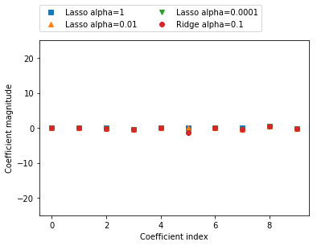

```python
#Plot the coefficents based on different alpha's in the lasso model
import matplotlib.pyplot as plt
plt.plot(lasso.coef_, 's', label="Lasso alpha=1")
plt.plot(lasso001.coef_, '^', label="Lasso alpha=0.01")
plt.plot(lasso00001.coef_, 'v', label="Lasso alpha=0.0001")
plt.plot(ridge01.coef_, 'o', label="Ridge alpha=0.1")
plt.legend(ncol=2, loc=(0, 1.05))
plt.ylim(-25, 25)
plt.xlabel("Coefficient index")
plt.ylabel("Coefficient magnitude")
#very little difference
```

#### Apply Scaler

```python
#apply standard scaler

from sklearn import preprocessing

scaler = preprocessing.StandardScaler()
scaler.fit(X_train)
X_train_scaled = scaler.transform(X_train)
ridge = Ridge().fit(X_train_scaled, y_train)
X_test_scaled = scaler.transform(X_test)
print(ridge.score(X_train_scaled, y_train))
print(ridge.score(X_test_scaled, y_test))
```

```
0.8054474937982297
0.8069708569856142
```

#### Min Max Scaler

```python
#apply min max scaler with ridge
scaler2 = preprocessing.MinMaxScaler()
scaler2.fit(X_train)
X_train_scaled = scaler2.transform(X_train)
ridge = Ridge().fit(X_train_scaled, y_train)
X_test_scaled = scaler2.transform(X_test)
print(ridge.score(X_train_scaled, y_train))
print(ridge.score(X_test_scaled, y_test))
```

```
0.8043785322808115
0.8000138348939225
```

```python
#pipeline with standard scaler and ridge
from sklearn.pipeline import make_pipeline

pipe = make_pipeline(StandardScaler(), Ridge())
pipe.fit(X_train, y_train)
print(pipe.score(X_train, y_train))
print(pipe.score(X_test, y_test))
```

```
0.8054474937982297
0.8069708569856142
```

Scaling the data with any of these techniques does not improve the model. I imagine since this is standardized education data, it might not need scaling in the same way other data sets might.

### 1.4 Tune the parameters of the models where possible using GridSearchCV. Do the results improve?

```python
from sklearn.pipeline import make_pipeline
from sklearn.neighbors import KNeighborsRegressor

knn_pipe = make_pipeline(StandardScaler(), KNeighborsRegressor())
print(knn_pipe.steps)
```

```
[('standardscaler', StandardScaler(copy=True, with_mean=True, with_std=True)), ('kneighborsregressor', KNeighborsRegressor(algorithm='auto', leaf_size=30, metric='minkowski',
          metric_params=None, n_jobs=1, n_neighbors=5, p=2,
          weights='uniform'))]
```

```python
#gridsearchcv
from sklearn.model_selection import GridSearchCV

knn_pipe = make_pipeline(StandardScaler(), KNeighborsRegressor())


param_grid = {'kneighborsregressor__n_neighbors': range(1, 10)}
grid = GridSearchCV(knn_pipe, param_grid, cv=10)
grid.fit(X_train, y_train)
print(grid.best_params_)
print(grid.score(X_train, y_train))
print(grid.score(X_test, y_test))
```

```
{'kneighborsregressor__n_neighbors': 7}
0.7971537696680577
0.7813329513145508
```

The results from the GridSearchCV did not improve the performance of the model. In fact, the performance declined to .79 and .78

### 1.5 Compare the coefficients of your two best linear models (not knn), do they agree on which features are important?

None of my lasso models agree on the number of features. The two best, which perform equally to the other best models, use 9 or 10 features, which makes me think that one of the features in the 10 doesn't help the model perform better or worse. If chosing between the two, I would pick the one with 9 features since it is simpler and performs just as well

### 1.6 Discuss which final model you would choose to predict new data

For the sake of simplicity, I'd choose the OLS model. OLS, Ridge and Lasso models all performed the same except for the first lasso with alpha 1, which performed just slighly worse. When the scalers and gridsearch were applied, th model did slightly worse, so I wouldn't use any of those techniques.

The cross validation techniques tell me there is some variance in how the model performs at different cuts of the data, but the mean is somewhat close to the performance of the model (.78) and the performance doesn't vary widely from these models.

## Part 2: Classification on red and white wine characteristics

```python
url1 = 'https://archive.ics.uci.edu/ml/machine-learning-databases/wine-quality/winequality-red.csv'
url2 = 'https://archive.ics.uci.edu/ml/machine-learning-databases/wine-quality/winequality-white.csv'
red = pd.read_csv(url1, sep=';')
white = pd.read_csv(url2, sep=';')

red['winetype'] = 1
white['winetype'] = 0

df = pd.concat([red, white])
```

```python
df.head()
```

|  | fixed acidity | volatile acidity | citric acid | residual sugar | chlorides | free sulfur dioxide | total sulfur dioxide | density | pH | sulphates | alcohol | quality | winetype |
| --- | --- | --- | --- | --- | --- | --- | --- | --- | --- | --- | --- | --- | --- |
| 0 | 7.4 | 0.70 | 0.00 | 1.9 | 0.076 | 11.0 | 34.0 | 0.9978 | 3.51 | 0.56 | 9.4 | 5 | 1 |
| 1 | 7.8 | 0.88 | 0.00 | 2.6 | 0.098 | 25.0 | 67.0 | 0.9968 | 3.20 | 0.68 | 9.8 | 5 | 1 |
| 2 | 7.8 | 0.76 | 0.04 | 2.3 | 0.092 | 15.0 | 54.0 | 0.9970 | 3.26 | 0.65 | 9.8 | 5 | 1 |
| 3 | 11.2 | 0.28 | 0.56 | 1.9 | 0.075 | 17.0 | 60.0 | 0.9980 | 3.16 | 0.58 | 9.8 | 6 | 1 |
| 4 | 7.4 | 0.70 | 0.00 | 1.9 | 0.076 | 11.0 | 34.0 | 0.9978 | 3.51 | 0.56 | 9.4 | 5 | 1 |

```python
df.info()
```

```
<class 'pandas.core.frame.DataFrame'>
Int64Index: 6497 entries, 0 to 4897
Data columns (total 13 columns):
fixed acidity           6497 non-null float64
volatile acidity        6497 non-null float64
citric acid             6497 non-null float64
residual sugar          6497 non-null float64
chlorides               6497 non-null float64
free sulfur dioxide     6497 non-null float64
total sulfur dioxide    6497 non-null float64
density                 6497 non-null float64
pH                      6497 non-null float64
sulphates               6497 non-null float64
alcohol                 6497 non-null float64
quality                 6497 non-null int64
winetype                6497 non-null int64
dtypes: float64(11), int64(2)
memory usage: 710.6 KB
```

### 2.1 Visualize the univariate distribution of the target feature and each of the three explanatory variables that you think are likely to have a relationship with the target feature.

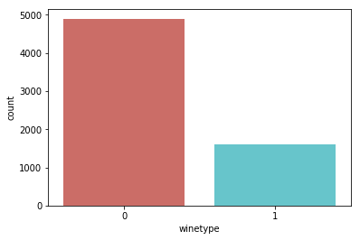

```python
#target variable distribution
sns.countplot(x='winetype', data=df,palette='hls')
plt.show()
```

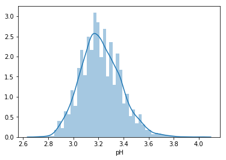

```python
#univariate plot of pH
sns.distplot(df.pH)
```

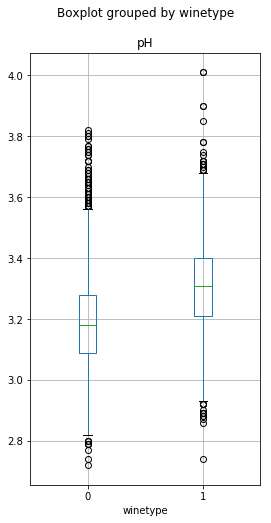

```python
#pH levels split by target variable
df.boxplot(column="pH",
          by = "winetype",
          figsize=(4,8))
```

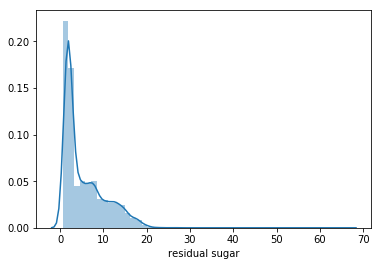

```python
#distribution of residual sugar
sns.distplot(df['residual sugar'])
```

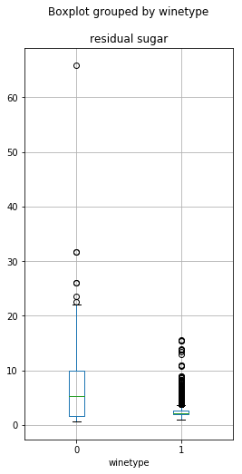

```python
#residual sugar levels split by target variable
df.boxplot(column="residual sugar",
          by = "winetype",
          figsize=(4,8))
```

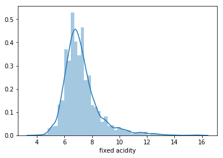

```python
#distribution of fixed acidity
sns.distplot(df['fixed acidity'])
```

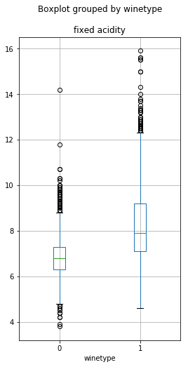

```python
#fixed acidity levels split by target variable
df.boxplot(column="fixed acidity",
          by = "winetype",
          figsize=(4,8))
```

### 2.2 Split data into training and test set. Build models that evaluate the relationship between all available X variables in the dataset and the target variable. Evaluate Logistic Regression, Penalized Logistic Regression, and KNN for classification using cross-validation. How different are the results? How does scaling the data with StandardScaler influence the results?

```python
#split into target and x variables
X = df.loc[:, df.columns != 'winetype']
y = df['winetype']

#split into train test data
X_train, X_test, y_train, y_test = train_test_split(X, y, random_state=42)
```

#### Logistic Regression

```python
#import logreg
from sklearn.linear_model import LogisticRegression

#Logistic Regression

logreg = LogisticRegression(C=1e90).fit(X_train, y_train)

print("logreg .coef_: {}".format(logreg .coef_))


print("Training set score: {:.3f}".format(logreg.score(X_train, y_train)))
print("Test set score: {:.3f}".format(logreg.score(X_test, y_test)))


predicted_vals = logreg.predict(X_test) # y_pred includes your predictions
print("logreg.predict: {}".format(predicted_vals))
```

```
logreg .coef_: [[  1.46606749  13.27105118  -0.25307856  -0.12243099  28.73141369
    0.06486612  -0.06938744 -19.50960751   8.73436874   9.13106397
   -0.51519118   0.04888584]]
Training set score: 0.990
Test set score: 0.986
logreg.predict: [0 1 0 ... 0 0 0]
```

#### Penalized Logistic Regression

```python
#Log Reg with Constrained Coefficients
logreg = LogisticRegression(C=100).fit(X_train, y_train)

print("logreg .coef_: {}".format(logreg .coef_))


print("Training set score: {:.3f}".format(logreg.score(X_train, y_train)))
print("Test set score: {:.3f}".format(logreg.score(X_test, y_test)))


predicted_vals = logreg.predict(X_test) # y_pred includes your predictions
print("logreg.predict: {}".format(predicted_vals))
```

```
logreg .coef_: [[ 1.47194611e+00  1.29579509e+01 -9.30223790e-01 -1.22032676e-01
   1.84768023e+01  6.12644356e-02 -6.82601562e-02 -1.85965731e+01
   8.42395219e+00  9.41050669e+00 -6.05826405e-01  9.03894531e-03]]
Training set score: 0.990
Test set score: 0.986
logreg.predict: [0 1 0 ... 0 0 0]
```

```python
#C=1,
logreg = LogisticRegression(C=1).fit(X_train, y_train)

print("logreg .coef_: {}".format(logreg .coef_))


print("Training set score: {:.3f}".format(logreg.score(X_train, y_train)))
print("Test set score: {:.3f}".format(logreg.score(X_test, y_test)))


predicted_vals = logreg.predict(X_test)
print("logreg.predict: {}".format(predicted_vals))
```

```
logreg .coef_: [[ 0.69335434  8.37505359 -0.65427274 -0.16141212  2.06120743  0.04789305
  -0.0642063  -2.52612275  2.00576397  6.74686051 -0.81536412 -0.08934838]]
Training set score: 0.983
Test set score: 0.977
logreg.predict: [0 0 0 ... 0 0 0]
```

```python
#c=.01

logreg = LogisticRegression(C=.01).fit(X_train, y_train)

print("logreg .coef_: {}".format(logreg .coef_))


print("Training set score: {:.3f}".format(logreg.score(X_train, y_train)))
print("Test set score: {:.3f}".format(logreg.score(X_test, y_test)))


predicted_vals = logreg.predict(X_test) # y_pred includes your predictions
print("logreg.predict: {}".format(predicted_vals))
```

```
logreg .coef_: [[ 0.74837661  0.633502   -0.1748245  -0.13042882  0.09278821  0.03407624
  -0.05961385  0.06491115  0.60526769  0.43317493 -0.32933468 -0.11657069]]
Training set score: 0.953
Test set score: 0.942
logreg.predict: [0 0 0 ... 0 0 0]
```

#### KNN

```python
#K nearest neighbors, n=5
from sklearn.neighbors import KNeighborsClassifier

knn = KNeighborsClassifier(n_neighbors=5)
knn.fit(X_train, y_train)

#Print accuracy rounded to two digits to the right of decimal
print("accuracy: {:.2f}".format(knn.score(X_train, y_train)))
print("accuracy: {:.2f}".format(knn.score(X_test, y_test)))


y_pred = knn.predict(X_test) # y_pred includes your predictions
```

```
accuracy: 0.96
accuracy: 0.94
```

```python
#K nearest neighbors, n=10
knn = KNeighborsClassifier(n_neighbors=10)
knn.fit(X_train, y_train)

#Print accuracy rounded to two digits to the right of decimal
print("accuracy: {:.2f}".format(knn.score(X_train, y_train)))
print("accuracy: {:.2f}".format(knn.score(X_test, y_test)))


y_pred = knn.predict(X_test) # y_pred includes your predictions
```

```
accuracy: 0.95
accuracy: 0.93
```

#### Cross Validation, KFold types

```python
#import packages for CV/Folds
from sklearn.model_selection import cross_val_score
from sklearn.model_selection import RepeatedKFold
from sklearn.model_selection import StratifiedKFold
from sklearn.model_selection import KFold
import numpy as np
from statistics import mean

# Set up function parameters for diff't cross validation strategies
kfold = KFold(n_splits=5)
skfold = StratifiedKFold(n_splits=5, shuffle=True)
rkf = RepeatedKFold(n_splits=5, n_repeats=10)



print("KFold:\n{}".format(
cross_val_score(KNeighborsClassifier(), X, y, cv=kfold)))

cvmean = np.mean(cross_val_score(LinearRegression(), X_train, y_train, cv=kfold))
print("Cross-validation mean: " + str(cvmean))


print("StratifiedKFold:\n{}".format(
cross_val_score(KNeighborsClassifier(n_neighbors=5), X, y, cv=skfold)))

cvmean = np.mean(cross_val_score(LinearRegression(), X_train, y_train, cv=skfold))
print("Cross-validation mean: " + str(cvmean))

print("RepeatedKFold:\n{}".format(
cross_val_score(KNeighborsClassifier(n_neighbors=5), X, y, cv=rkf)))
cvmean = np.mean(cross_val_score(LinearRegression(), X_train, y_train, cv=rkf))
print("Cross-validation mean: " + str(cvmean))
```

```
KFold:
[0.72307692 0.93923077 0.95842956 0.96458814 0.95919938]
Cross-validation mean: 0.8530803165350868
StratifiedKFold:
[0.94230769 0.94153846 0.94538462 0.93918399 0.94144838]
Cross-validation mean: 0.8533791434819091
RepeatedKFold:
[0.94307692 0.93615385 0.94534257 0.94149346 0.94919169 0.94307692
 0.94076923 0.94611239 0.9430331  0.94842186 0.94076923 0.94923077
 0.94380293 0.94688222 0.93456505 0.94230769 0.95153846 0.94149346
 0.93995381 0.93533487 0.93923077 0.94461538 0.94765204 0.94226328
 0.94380293 0.94       0.94307692 0.94380293 0.93533487 0.9430331
 0.93461538 0.94538462 0.94072363 0.9361047  0.94534257 0.94923077
 0.93846154 0.93764434 0.93148576 0.94688222 0.93       0.95461538
 0.94457275 0.94842186 0.94149346 0.94692308 0.94769231 0.9361047
 0.9430331  0.9361047 ]
Cross-validation mean: 0.8552089973556254
```

#### Standard Scaler

```python
#add standard scaler to logreg
scaler = preprocessing.StandardScaler()
scaler.fit(X_train)
X_train_scaled = scaler.transform(X_train)
logreg = LogisticRegression().fit(X_train_scaled, y_train)
X_test_scaled = scaler.transform(X_test)
print(logreg.score(X_train_scaled, y_train))
print(logreg.score(X_test_scaled, y_test))
```

```
0.9942528735632183
0.9907692307692307
```

The models performance varies between each technique, though all perform relatively well. There is much more variation between the models than with the previous data set where we used linear regression techniques.

The first Logistic Regression model performed the best and when we applied the standard scaler to it, it performed even better, closing the gap between the test and training performance. Helping the model generalize even better.

### 2.3 Tune the parameters where possible using GridSearchCV. Do the results improve?

```python
X_train, X_test, y_train, y_test = train_test_split(X, y, stratify=y)

#create dictionary data object with keys equal to parameter name 'n_neighbors'
#for knn model and values equal to range of k values to create models for

param_grid = {'n_neighbors': np.arange(1, 15, 2)} #np.arange creates sequence of numbers for each k value

grid = GridSearchCV(KNeighborsClassifier(), param_grid=param_grid, cv=skfold)

#use meta model methods to fit score and predict model:
grid.fit(X_train, y_train)

#extract best score and parameter by calling objects "best_score_" and "best_params_"
print("best mean cross-validation score: {:.3f}".format(grid.best_score_))
print("best parameters: {}".format(grid.best_params_))
print("test-set score: {:.3f}".format(grid.score(X_test, y_test)))
```

```
best mean cross-validation score: 0.946
best parameters: {'n_neighbors': 1}
test-set score: 0.948
```

The results do not improve and only one parameter is used in KNN.

### 2.4 Change the cross-validation strategy in GridSearchCV from ‘stratified k-fold’ to ‘kfold’ with shuffling. Do the parameters for models that can be tuned change? Do they change if you change the random seed of the shuffling? Or if you change the random state of the split into training and test data?

```python
#create dictionary data object with keys equal to parameter name 'n_neighbors'
#for knn model and values equal to range of k values to create models for

param_grid = {'n_neighbors': np.arange(1, 10, 5)} #np.arange creates sequence of numbers for each k value

grid = GridSearchCV(KNeighborsClassifier(), param_grid=param_grid, cv=kfold)

#use meta model methods to fit score and predict model:
grid.fit(X_train, y_train)

#extract best score and parameter by calling objects "best_score_" and "best_params_"
print("best mean cross-validation score: {:.3f}".format(grid.best_score_))
print("best parameters: {}".format(grid.best_params_))
print("test-set score: {:.3f}".format(grid.score(X_test, y_test)))
```

```
best mean cross-validation score: 0.945
best parameters: {'n_neighbors': 1}
test-set score: 0.945
```

```python
#create dictionary data object with keys equal to parameter name 'n_neighbors'
#for knn model and values equal to range of k values to create models for

param_grid = {'n_neighbors': np.arange(1, 10, 5)} #np.arange creates sequence of numbers for each k value

grid = GridSearchCV(KNeighborsClassifier(), param_grid=param_grid, cv=rkf)

#use meta model methods to fit score and predict model:
grid.fit(X_train, y_train)

#extract best score and parameter by calling objects "best_score_" and "best_params_"
print("best mean cross-validation score: {:.3f}".format(grid.best_score_))
print("best parameters: {}".format(grid.best_params_))
print("test-set score: {:.3f}".format(grid.score(X_test, y_test)))
```

```
best mean cross-validation score: 0.945
best parameters: {'n_neighbors': 1}
test-set score: 0.945
```

```python
X_train, X_test, y_train, y_test = train_test_split(X, y, stratify=y, random_state=43)

param_grid = {'n_neighbors': np.arange(1, 10, 5)} #np.arange creates sequence of numbers for each k value

grid = GridSearchCV(KNeighborsClassifier(), param_grid=param_grid, cv=kfold)

#use meta model methods to fit score and predict model:
grid.fit(X_train, y_train)

#extract best score and parameter by calling objects "best_score_" and "best_params_"
print("best mean cross-validation score: {:.3f}".format(grid.best_score_))
print("best parameters: {}".format(grid.best_params_))
print("test-set score: {:.3f}".format(grid.score(X_test, y_test)))
```

```
best mean cross-validation score: 0.945
best parameters: {'n_neighbors': 1}
test-set score: 0.945
```

The paramenters appear not to change.

### 2.5 Lastly, compare the coefficients for Logistic Regression and Penalized Logistic Regression and discuss which final model you would choose to predict new data.

I would choose the first model, Logistic Regression, with the standard scaler applied because it performed the best, with 99% accuracy for both the training and test data, which is almost perfect. It generalized well and is very accurate.